# chapter 5

# CHAPTER 5: dimension reduction

In this chapter, we are working with the ‘human’ dataset. It’s a data from the UN, aiming to describe many, measureable aspects of development level - not only economic growth. The aim of the data is to calculcate ‘HDI’, human development index. HDI is a mean of three indices - education index, life expectancy index, and GNI index (gross national income).

```r
path <- "/Users/pecsi_max/Desktop/GitHub/IODS-project/data/human"

#setting the "row.names = 1" indicates that rowames come as row names, not as a separate variable
human <- read.csv(path, row.names = 1)
dim(human)
```

```
## [1] 155   8
```

```r
str(human)
```

```
## 'data.frame':    155 obs. of  8 variables:
##  $ edu_ratio     : num  1.007 0.997 0.983 0.989 0.969 ...
##  $ part_ratio    : num  0.891 0.819 0.825 0.884 0.829 ...
##  $ edu_exp       : num  17.5 20.2 15.8 18.7 17.9 16.5 18.6 16.5 15.9 19.2 ...
##  $ life_exp      : num  81.6 82.4 83 80.2 81.6 80.9 80.9 79.1 82 81.8 ...
##  $ gni           : int  64992 42261 56431 44025 45435 43919 39568 52947 42155 32689 ...
##  $ mat_mort_ratio: int  4 6 6 5 6 7 9 28 11 8 ...
##  $ ado_birthr    : num  7.8 12.1 1.9 5.1 6.2 3.8 8.2 31 14.5 25.3 ...
##  $ parli_f       : num  39.6 30.5 28.5 38 36.9 36.9 19.9 19.4 28.2 31.4 ...
```

## The data

- edu_ratio: Ratio of females with at least secondary education to males with at least secondary education
- part_ratio: ratio of females to males who are in the active labour force
- edu_exp: expected years of education
- life_exp: life expectancy
- gni: gross national income
- mat_mort_ratio: maternal mortality ratio
- ado_birthr: adolescent birth rate
- parli_f: percentage of female representatives in parliament

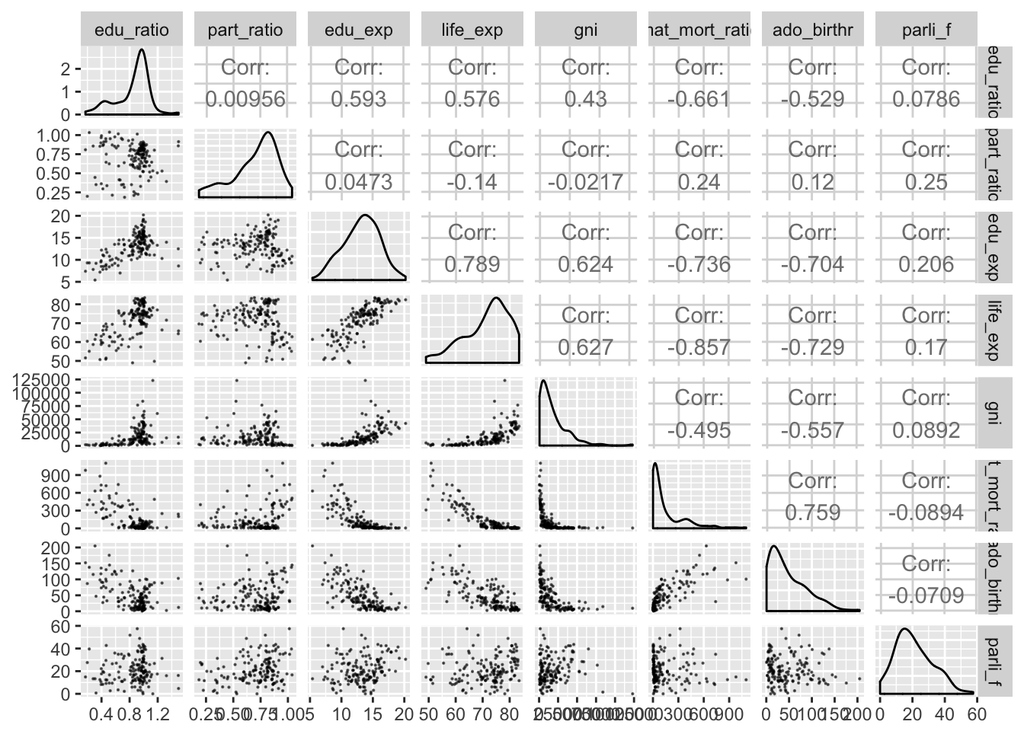

Each observation is a value from a single country, so we look at the distribution of the world. slightly two-peaked distributions are seen in maternal mortality, life-expectancy, education ratio. Quite strong correlations are seen with some variables, which might indicate good use of factor analysis.

Next, we’ll do the PCA without scaling the dataset.

## PCA

### PCA without scaling

```r
pca_human_notscaled <- prcomp(human)
summary(pca_human_notscaled)
```

```
## Importance of components:
##                              PC1      PC2   PC3   PC4   PC5   PC6    PC7
## Standard deviation     1.854e+04 185.5219 25.19 11.45 3.766 1.566 0.1912
## Proportion of Variance 9.999e-01   0.0001  0.00  0.00 0.000 0.000 0.0000
## Cumulative Proportion  9.999e-01   1.0000  1.00  1.00 1.000 1.000 1.0000
##                           PC8
## Standard deviation     0.1591
## Proportion of Variance 0.0000
## Cumulative Proportion  1.0000
```

[output not shown]

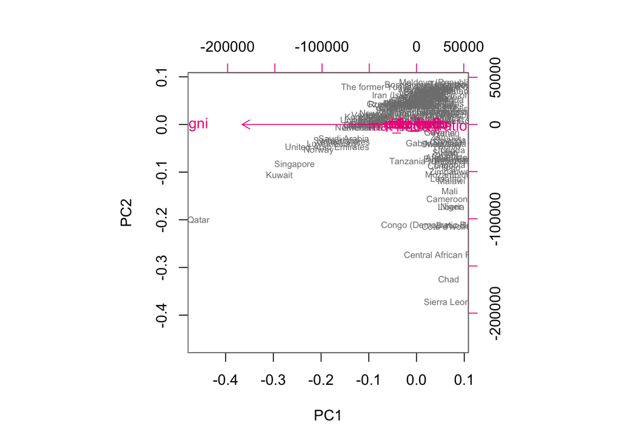

```r
biplot(pca_human_notscaled, choices = 1:2, cex = c(0.6, 1), col = c("grey50", "deeppink2"))
```

Looks like the first component would explain almost all variance in the data. That is gross national income. This is probably due to the dataset not being scaled, and GNI probably is numerically very large. We also got some warnings of zero-length arrows, probably reflecting the same phenomenom

Next, we’ll scale the data and try PCA again. The summary of the scaled data will not be shown.

### PCA with scaled data

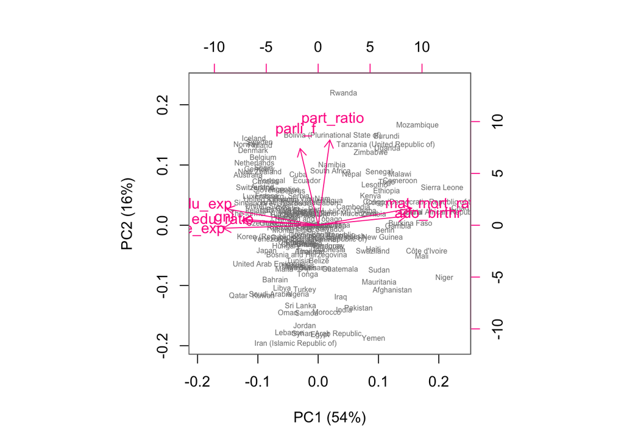

```r
human_scaled <- scale(human)

pca_human_scaled <-  prcomp(human_scaled)

s <- summary(pca_human_scaled)
pca_pr <- round(100*s$importance[2,], digits = 0)

pc_lab <- paste0(names(pca_pr), " (", pca_pr, "%)")

biplot(pca_human_scaled, choices = 1:2, cex = c(0.5, 1), col = c("grey50", "deeppink1"),
       xlab = pc_lab[1], ylab = pc_lab[2])
```

### Interpretations

Now the variances explained, as well as the arrow graph, look better. PCA is sensitive to the absolute numerical parameters of the variables, this is why it requires scaling.

In the plot are shown the two first PC:s and how the original variables contribute to the PC:s. Looks like that the second PC describes the variables ‘parli_f’ and ‘part_ratio’, i.e. the ratio of females in parliament and in labour force. Interestingly, education is not there.

All other varibales seem to contribute to the 1st PC. They are rather clear measurements of how developed a society is (maternal mortality ratio, gni etc). Perhaps the second PC reflects some kind of conservative values, that can occur in even developed nations.

On the other hand, maternal mortality ratio and adolescent birth rate appear to be very closely correlated to each other, and inversely with other horizontal arrows.

## The next data

“Tea” dataset from the Factominer package. It is a dataset containing a large number of factor variables, many of which are binary. It’s a data of a questionnaire measuring tea consumption and related things.

We select only certain columns to keep, and take a glimpse of the distribution of these columns.

```r
library(FactoMineR)
data("tea")

str(tea)
```

```
## 'data.frame':    300 obs. of  36 variables:
##  $ breakfast       : Factor w/ 2 levels "breakfast","Not.breakfast": 1 1 2 2 1 2 1 2 1 1 ...
##  $ tea.time        : Factor w/ 2 levels "Not.tea time",..: 1 1 2 1 1 1 2 2 2 1 ...
##  $ evening         : Factor w/ 2 levels "evening","Not.evening": 2 2 1 2 1 2 2 1 2 1 ...
##  $ lunch           : Factor w/ 2 levels "lunch","Not.lunch": 2 2 2 2 2 2 2 2 2 2 ...
##  $ dinner          : Factor w/ 2 levels "dinner","Not.dinner": 2 2 1 1 2 1 2 2 2 2 ...
##  $ always          : Factor w/ 2 levels "always","Not.always": 2 2 2 2 1 2 2 2 2 2 ...
##  $ home            : Factor w/ 2 levels "home","Not.home": 1 1 1 1 1 1 1 1 1 1 ...
##  $ work            : Factor w/ 2 levels "Not.work","work": 1 1 2 1 1 1 1 1 1 1 ...
##  $ tearoom         : Factor w/ 2 levels "Not.tearoom",..: 1 1 1 1 1 1 1 1 1 2 ...
##  $ friends         : Factor w/ 2 levels "friends","Not.friends": 2 2 1 2 2 2 1 2 2 2 ...
##  $ resto           : Factor w/ 2 levels "Not.resto","resto": 1 1 2 1 1 1 1 1 1 1 ...
##  $ pub             : Factor w/ 2 levels "Not.pub","pub": 1 1 1 1 1 1 1 1 1 1 ...
##  $ Tea             : Factor w/ 3 levels "black","Earl Grey",..: 1 1 2 2 2 2 2 1 2 1 ...
##  $ How             : Factor w/ 4 levels "alone","lemon",..: 1 3 1 1 1 1 1 3 3 1 ...
```

[output cut: 22 more lines]

```r
dim(tea)
```

```
## [1] 300  36
```

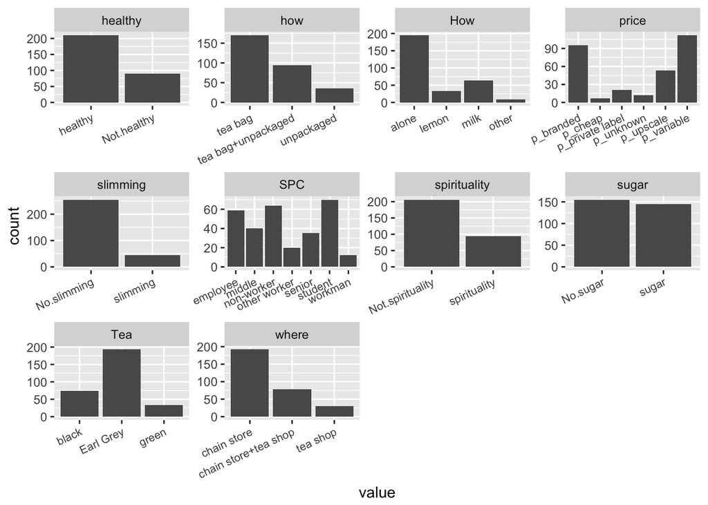

```r
teavars <- c("Tea", "How", "how", "sugar", "where", "price", "spirituality", "healthy", "slimming", "SPC")

tea_time <- dplyr::select(tea, one_of(teavars))


gather(tea_time) %>%
  ggplot(aes(value)) +
  geom_bar() +
  facet_wrap("key", scales = "free") +
  theme(
    axis.text.x = element_text(angle = 25, hjust = 1, size = 8))
```

Multiple correspondence analysis is a generalisation of PCA. The plot is similar to biplot, plotting the two firsts components. Colors represent the variables, and the distance of two points reflect how ‘similar’ they are in relation of the component.

```r
# multiple correspondence analysis
mca <- MCA(tea_time, graph = FALSE)

summary(mca)
```

```
##
## Call:
## MCA(X = tea_time, graph = FALSE)
##
##
## Eigenvalues
##                        Dim.1   Dim.2   Dim.3   Dim.4   Dim.5   Dim.6
## Variance               0.225   0.179   0.159   0.140   0.138   0.118
## % of var.              9.377   7.478   6.627   5.814   5.731   4.901
## Cumulative % of var.   9.377  16.855  23.482  29.296  35.027  39.929
##                        Dim.7   Dim.8   Dim.9  Dim.10  Dim.11  Dim.12
## Variance               0.113   0.110   0.106   0.104   0.098   0.097
## % of var.              4.689   4.587   4.419   4.313   4.094   4.023
## Cumulative % of var.  44.618  49.205  53.623  57.936  62.030  66.053
##                       Dim.13  Dim.14  Dim.15  Dim.16  Dim.17  Dim.18
## Variance               0.092   0.089   0.087   0.085   0.076   0.071
## % of var.              3.840   3.701   3.617   3.562   3.179   2.965
## Cumulative % of var.  69.893  73.594  77.211  80.774  83.953  86.918
##                       Dim.19  Dim.20  Dim.21  Dim.22  Dim.23  Dim.24
## Variance               0.065   0.064   0.059   0.052   0.044   0.030
## % of var.              2.720   2.651   2.470   2.170   1.831   1.239
## Cumulative % of var.  89.638  92.289  94.759  96.929  98.761 100.000
##
## Individuals (the 10 first)
##                       Dim.1    ctr   cos2    Dim.2    ctr   cos2    Dim.3
## 1                  | -0.194  0.056  0.010 |  0.482  0.431  0.062 |  0.049
## 2                  |  0.038  0.002  0.001 |  0.160  0.048  0.014 |  0.421
## 3                  | -0.226  0.075  0.025 | -0.010  0.000  0.000 | -0.020
## 4                  | -0.459  0.312  0.187 | -0.216  0.087  0.042 | -0.411
## 5                  | -0.313  0.145  0.071 | -0.210  0.082  0.032 | -0.290
## 6                  | -0.508  0.382  0.123 |  0.207  0.080  0.020 | -0.219
## 7                  | -0.113  0.019  0.009 | -0.181  0.061  0.024 |  0.026
## 8                  |  0.038  0.002  0.001 |  0.160  0.048  0.014 |  0.421
## 9                  |  0.599  0.531  0.141 | -0.594  0.655  0.138 | -0.022
## 10                 |  0.776  0.891  0.263 | -0.469  0.409  0.096 |  0.326
##                       ctr   cos2
## 1                   0.005  0.001 |
## 2                   0.372  0.097 |
## 3                   0.001  0.000 |
## 4                   0.354  0.150 |
```

[output cut: 28 more lines]

```
## tea bag+unpackaged   0.485 -12.042 |  -0.049   0.048   0.001  -0.576 |
## unpackaged           0.148   6.657 |  -0.565   2.406   0.043  -3.606 |
##
## Categorical variables (eta2)
##                      Dim.1 Dim.2 Dim.3
## Tea                | 0.114 0.100 0.225 |
## How                | 0.043 0.054 0.301 |
## how                | 0.568 0.533 0.051 |
## sugar              | 0.062 0.000 0.100 |
## where              | 0.678 0.544 0.097 |
## price              | 0.578 0.337 0.039 |
## spirituality       | 0.001 0.066 0.008 |
## healthy            | 0.000 0.001 0.219 |
## slimming           | 0.008 0.074 0.232 |
## SPC                | 0.198 0.086 0.318 |
```

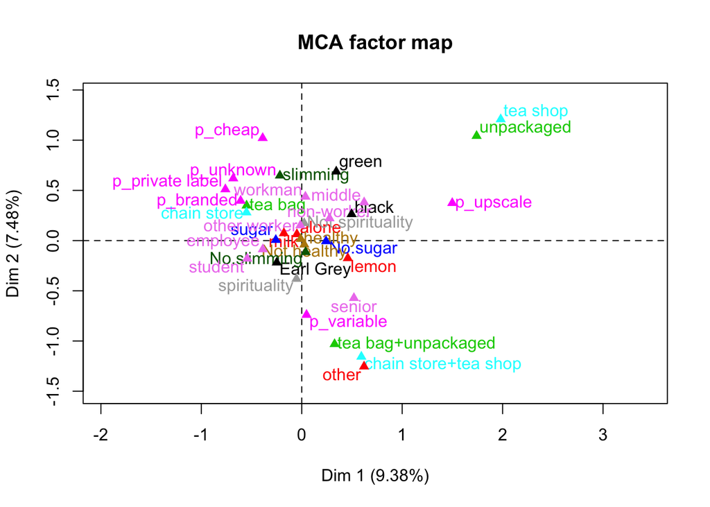

```r
# visualize MCA
plot(mca, invisible=c("ind"), habillage = "quali")
```

First looking at the positions to x-axis, tea shop and unpacked tea stand out. In the other end there are p_cheap, chain store, slimming, p_branded, and sugar. Could this represent how much people value the “quality” and “finesse” of the tea? To clarify, those people who put sugar in their tea perhaps are not that interested about the details in the taste. Same goes for those who buy their tea in supermarkets, or drink tea because they think it’s good for weight loss.

In y-axis, it’s actually really hard to say! In the bottom, there are some variables reflecting large variability: other, p_variable, tea bag + unpacked etc. Perhaps they are the people who drink tea in many forms, or then are not so strict in their preferences?